# defects_dbrics

## 🎯 Project Goal

This project implements an **event-driven Azure Data Engineering pipeline** using  
**Azure Data Factory, Databricks, Delta Lake, and the Medallion Architecture (Bronze → Silver → Gold)**.

The pipeline is triggered automatically on **file upload to Azure Blob Storage** and processes  
a **single incoming data file** end-to-end — from raw ingestion to a curated dataset stored  
in **Azure SQL Database** for analytics and reporting.

The solution follows **modern lakehouse and data governance practices**, leveraging  
**Databricks Unity Catalog** for centralized access control over curated data.

The goal of this project is to demonstrate **production-oriented Data Engineering skills**, including:

- event-driven orchestration with **Azure Data Factory**
- distributed data processing using **PySpark**
- **Delta Lake** ACID layers and Medallion Architecture
- centralized data governance using **Unity Catalog**
- secure access via external locations (no credentials in code)
- data validation, transformations, and KPI-ready outputs
- clean, maintainable, and scalable pipeline design

## 🧰 Technologies and Tools

| Category | Technology | Purpose |
| --- | --- | --- |
| Orchestration | **Azure Data Factory** | Event-driven pipeline orchestration |
| Processing | **Databricks (PySpark)** | Distributed ETL & transformations |
| Storage | **Azure Data Lake Storage Gen2 (ADLS Gen2)** | Raw & curated data storage |
| Lakehouse | **Delta Lake** | ACID tables, schema enforcement |
| Architecture | **Medallion (Bronze/Silver/Gold)** | Layered data refinement |
| Governance | **Databricks Unity Catalog** | Centralized data access & permissions |
| Sink | **Azure SQL Database** | Analytics-ready relational storage |
| Monitoring | Python `logging` | Processing & error logging |

## 🏗️ High-Level Architecture

Below is the high-level architecture of the pipeline:

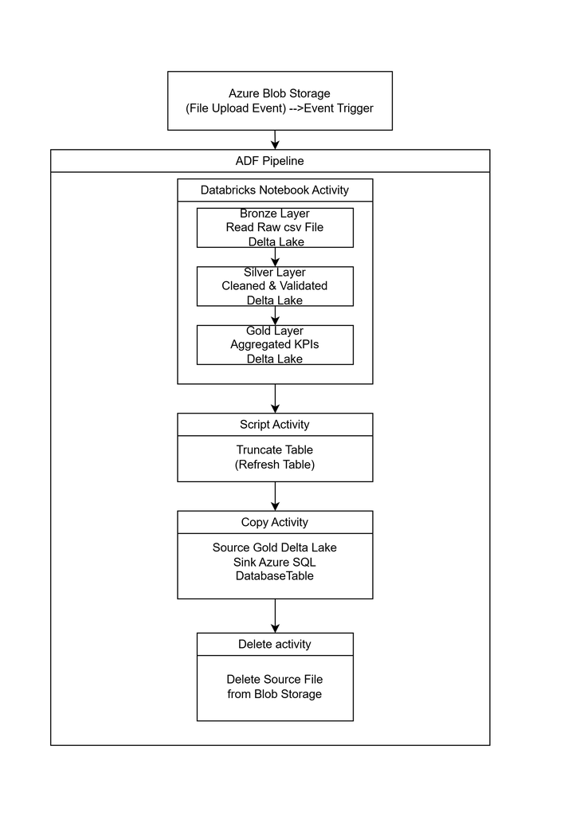

**Flow overview:**

1. File uploaded to Azure Blob Storage (event trigger)
2. Azure Data Factory pipeline starts automatically
3. Databricks notebook processes data using Medallion Architecture
4. Gold data written to Delta Lake
5. Curated dataset copied into Azure SQL Database
6. Source file cleanup after successful processing

This architecture enables **fully automated, scalable, and governed data processing**.

## 🔄 Azure Data Factory Pipeline

The pipeline is fully automated and event-driven.

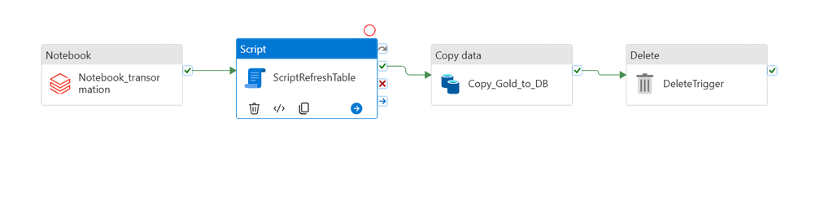

The pipeline is designed for **idempotent, production-style execution**.

## 🔐 Data Governance & Connectivity

This project follows **modern cloud governance best practices**.

🔶 Databricks workspace & metastore:

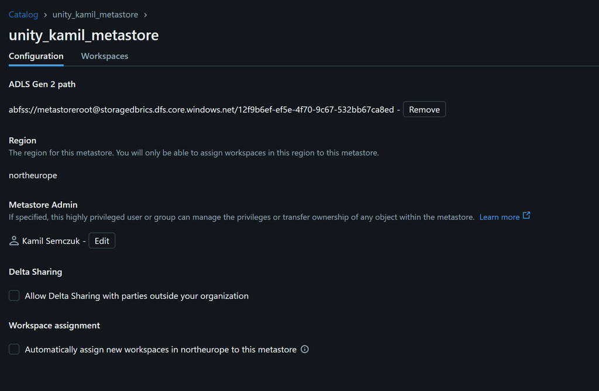

Key principles:

- **Unity Catalog** manages access to curated data
- **External Locations** define governed access to storage paths
- No secrets or credentials stored in notebooks
- Permissions enforced centrally at the metastore level
- Clean separation between storage, processing, and access control

This setup reflects **enterprise-grade lakehouse governance**.

🔶 Databricks notebook linked service:

[figure not shown]

🗄️ Azure SQL Database linked service:

[figure not shown]

## 🥉 Bronze Layer – Raw Ingestion

The Bronze layer stores **raw-but-validated** data in Delta format.

### What happens in Bronze:

- Read uploaded source file from Blob Storage
- Write raw data to **Bronze Delta tables**

Data is preserved as close to the original source as possible.

## 🥈 Silver Layer – Cleaning & Transformation

The Silver layer produces **clean, normalized, and validated** data.

### Processing steps:

- Read data from Bronze Delta tables
- Data cleaning (null handling, deduplication)
- Type casting & schema enforcement
- Business rule validation
- Data normalization for analytics
- Write curated dataset to **Silver Delta tables**

At this stage, the data is reliable and analytics-ready.

## 🥇 Gold Layer – Curated Output

The Gold layer contains **final, consumption-ready data**.

### Gold processing:

- Read data from Silver Delta tables
- Final transformations & formatting
- Overwrite Gold Delta table with curated output
- Prepare schema for downstream systems

The Gold table acts as the **single source of truth**.

## 📤 Data Sink – Azure SQL Database

The final Gold dataset is loaded into **Azure SQL Database** using an ADF Copy Activity.

Purpose:

- Enable easy access for BI tools and applications
- Provide relational, query-optimized storage
- Support reporting and downstream analytics

✴️Image of wild card used in data source in copy activity:

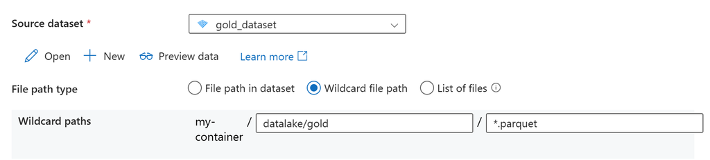

## 🧠 Logging & Observability

Basic logging is implemented inside the Databricks notebook:

- Read start / success
- Transformation completion
- Write success / failure
- Error handling and exceptions

This enables traceability and easier debugging.

## 🚀 Possible Enhancements

- Add metadata-driven ingestion (multiple files / folders)
- Introduce data quality checks (e.g. Great Expectations)
- Parameterize pipeline for multiple datasets
- Add monitoring & alerting for pipeline failures
- Implement incremental or CDC-based processing
- Optimize parallel execution for larger data volumes

## 🧠 What I Learned

- Designing **event-driven Azure Data Engineering pipelines**
- Integrating **ADF and Databricks** in production-style workflows
- Applying **Medallion Architecture** correctly with Delta Lake
- Using **Unity Catalog** for governed data access
- Writing clean, maintainable PySpark ETL code
- Delivering analytics-ready data to relational systems